# Introducción a R y Rstudio

# Otros aspectos de R

## Proyecto dentro de RStudio

- Para crear un proyecto, vamos a la esquina derecha de la barra de herramientas:

[figure not shown]

- También podemos hacer lo mismo desde **File > New Project…**
- Le vamos a poner el nombre **proyectoR**.

[figure not shown]

[figure not shown]

[figure not shown]

[figure not shown]

### Directorios del proyecto

- Normalmente, para proyectos simples, podemos poner todos los ficheros (scripts de R, datos, docs, informes, etc) en la misma carpeta del proyecto.
- Sin embargo, es una buena práctica, crear los siguientes directorios en cada proyecto:
- `R`: contendrá los scripts de R que se vayan desarrollando.
- `data`: almacenará los datos necesarios para realizar los análisis.
- `doc`: contendrá toda la documentación necesario para los análisis.
- `informes`: carpeta que guardará los informes generados por los análisis.
- En principio, solo vamos a crear las carpetas `R` y `data`.
- Vamos al panel de ficheros:

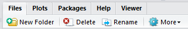

- Hacemos clic en **New Folder**, y le damos el nombre `R`.
- Haremos lo mismo para crear la carpeta `data`.
- Por tanto, la carpeta del proyecto quedaría como:

[figure not shown]

## Atajos de teclado

- Como se ha visto a lo largo de este curso sobre RStudio, existen múltiples formas de realizar la misma acción dentro del entorno, a saber, desde los botones, el menú o los atajos de teclado.
- En cada apartado, se han ido comentado algunos atajos de teclado que pueden resultar interesantes.
- La tabla que contiene todos los atajos se puede obtener en el menú **Tools > Keyboard Shortcuts Help**.

[figure not shown]

# Referencias

- [RStudio Support](https://support.rstudio.com/hc/en-us/categories/200035113-Documentation): web de soporte de RStudio.
- [RStudio Training](http://www.rstudio.com/training): página de formación de RStudio.
- [Google’s R Style Guide](http://google-styleguide.googlecode.com/svn/trunk/Rguide.xml): guía de estilo de programación en R según Google.